# Animasi dari Grafik

Muhammad Aswan Syahputra

Pembuatan animasi dari grafik statis yang diolah menggunakan paket ggplot2 dapat dilakukan dengan menggunakan paket gganimate. Anda dipersilahkan untuk mengaktifkan kedua paket tersebut dengan mengisi bagian ___ berikut dengan jawaban yang tepat. Selain itu dalam modul ini kita akan menggunakan tema flat dark dari paket ggthemr (paket ggthemr dapat dipasang dengan menjalankan fungsi `remotes::install_github('cttobin/ggthemr')`).

```r
library(ggplot2)
library(gganimate)
library(ggthemr) # Dipasang dengan cara menjalankan kode: remotes::install_github('cttobin/ggthemr')
ggthemr("flat dark", type = "outer") # Anda juga dapat menggunakan tema lain. Pilihan tema dapat dilihat di https://github.com/cttobin/ggthemr#palettes
```

Anda akan menggunakan dataset weather yang memiliki informasi mengenai data cuaca di beberapa lokasi di area Bandung. Dataset tersebut tersimpan pada direktori data-raw dengan nama weather.rda. Pergunakan fungsi `load()` untuk mengimpor dataset tersebut menjadi obyek R dengan nama weather dan kemudian pelajarilah strukturnya. Ada berapa lokasi dan variabel cuaca yang terdapat dalam dataset tersebut? Kapan observasi tersebut dimulai dan diakhiri?

```r
load("../data/weather.rda")
weather
```

```
## # A tibble: 476 x 5
##    location time                temperature pressure windspeed
##    <chr>    <dttm>                    <dbl>    <dbl>     <dbl>
##  1 Lembang  2015-01-04 07:00:00        20.7    1011.     0.774
##  2 Lembang  2015-01-04 08:00:00        17.5    1013.     4.49
##  3 Lembang  2015-01-04 09:00:00        18.1    1012.     6.63
##  4 Lembang  2015-01-04 10:00:00        17.5    1012.     9.62
##  5 Lembang  2015-01-04 11:00:00        18.8    1011.    10.1
##  6 Lembang  2015-01-04 12:00:00        19.2    1011.     8.71
##  7 Lembang  2015-01-04 13:00:00        19.3    1011.     8.37
##  8 Lembang  2015-01-04 14:00:00        19.1    1011.     7.79
##  9 Lembang  2015-01-04 15:00:00        19.6    1011.     9.34
## 10 Lembang  2015-01-04 16:00:00        19.2    1011.     7.76
## # ... with 466 more rows
```

```r
str(weather)
```

```
## Classes 'spec_tbl_df', 'tbl_df', 'tbl' and 'data.frame': 476 obs. of  5 variables:
##  $ location   : chr  "Lembang" "Lembang" "Lembang" "Lembang" ...
##  $ time       : POSIXct, format: "2015-01-04 07:00:00" "2015-01-04 08:00:00" ...
##  $ temperature: num  20.7 17.5 18.1 17.5 18.8 ...
##  $ pressure   : num  1011 1013 1012 1012 1011 ...
##  $ windspeed  : num  0.774 4.49 6.629 9.621 10.063 ...
```

```r
summary(weather)
```

```
##    location              time                      temperature
##  Length:476         Min.   :2015-01-04 07:00:00   Min.   :16.05
##  Class :character   1st Qu.:2015-01-04 23:45:00   1st Qu.:20.07
##  Mode  :character   Median :2015-01-05 16:30:00   Median :21.58
##                     Mean   :2015-01-05 16:30:00   Mean   :22.00
##                     3rd Qu.:2015-01-06 09:15:00   3rd Qu.:24.40
##                     Max.   :2015-01-07 02:00:00   Max.   :28.10
##     pressure      windspeed
##  Min.   :1008   Min.   : 0.2215
##  1st Qu.:1010   1st Qu.: 2.5983
##  Median :1010   Median : 3.8820
##  Mean   :1010   Mean   : 3.8483
##  3rd Qu.:1011   3rd Qu.: 5.1441
##  Max.   :1013   Max.   :10.0632
```

Sekarang buatlah *line graph* untuk mengamati pola perubahan suhu terhadap waktu dengan menggunakan ggplot2 dan simpan hasilnya ke dalam obyek R bernama plot_temperature! Pergunakan warna garis yang berbeda untuk setiap lokasi dan atur semua ketebalan garis menjadi 0.8.

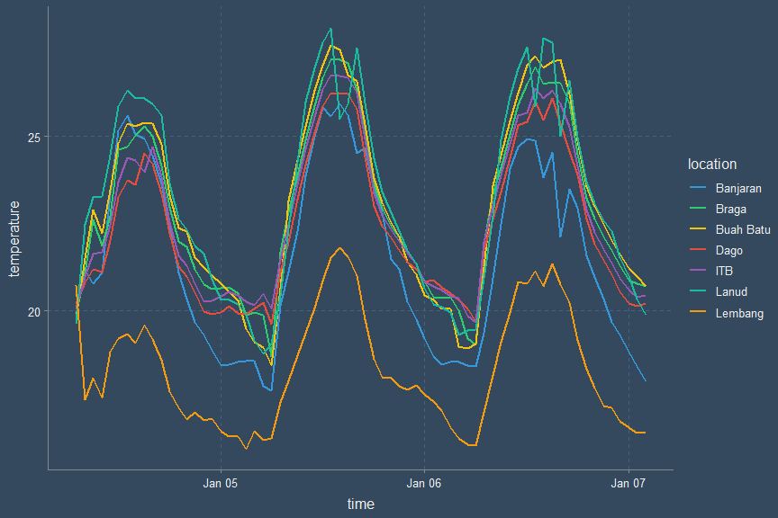

```r
plot_temperature <-
  ggplot(weather, aes(x = time , y = temperature, colour = location)) +
  geom_line(lwd = 0.8)
plot_temperature
```

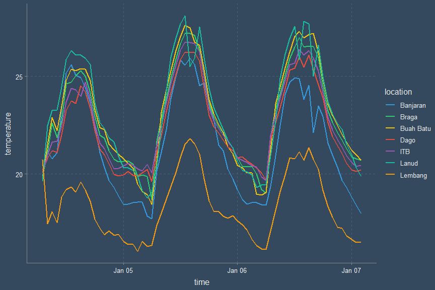

```r
plot_temperature2 <-
  plot_temperature +
  scale_x_datetime(date_breaks = "9 hours") +
  theme(
    axis.text.x = element_text(angle = 30, hjust = 1, vjust = 1),
    legend.position = "bottom"
  ) +
  labs(
    x = "Waktu",
    y = "Celcius",
    colour = NULL
  )
plot_temperature
```

Sekarang Anda dapat mengubah grafik statis diatas menjadi animasi dengan menggunakan fungsi dari paket gganimate. Apa yang akan terjadi jika Anda menambahkan baris kode `transition_reveal(time)` pada plot_temperature?

[figure not shown]

```r
plot_temperature +
  transition_reveal(time)
```

Selamat Anda telah berhasil membuat animasi pertama dari grafik menggunakan paket ggplot2 dan gganimate! Anda dapat berkesperimen membuat animasi serupa dengan menggunakan variabel pressure atau windspeed dari dataset weather tersebut.

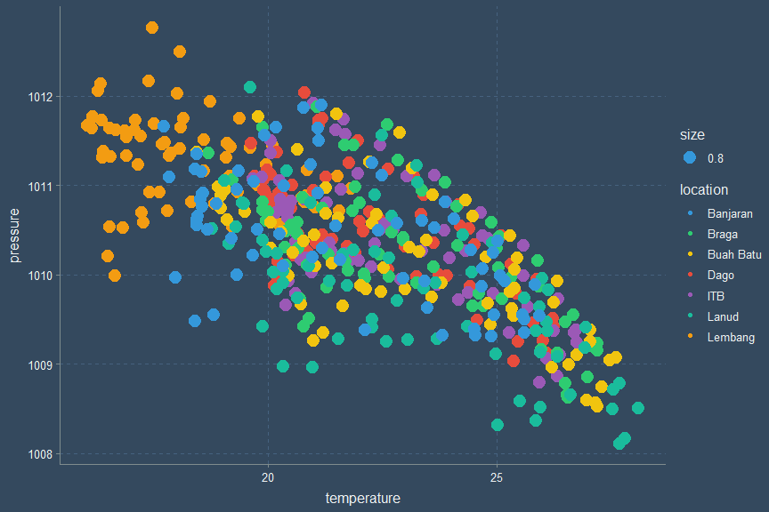

```r
plot_weather <- ggplot(weather, aes(x = temperature, y = pressure, colour = location, size = 0.8)) +
  geom_point()
plot_weather
```

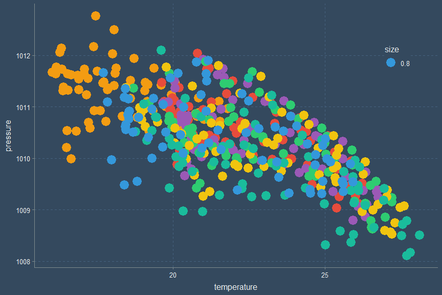

```r
plot_weather2 <-
  plot_weather +
  scale_size_area() +
  guides(colour = FALSE) +
  theme(
    legend.position = c(0.9, 0.8)
  )
plot_weather2
```

Sekarang Anda dapat membuat animasi dengan menggunakan fungsi `transition_states()` dari paket gganimate. Fungsi tersebut digunakan untuk membuat animasi yang membagi data menjadi beberapa kondisi, mirip dengan fungsi `facet_wrap()` untuk grafik statis. Isilah bagian ___ dengan nama variabel dari dataset weather yang menunjukan lokasi pengamatan untuk membuat animasi dengan nama animate_weather!

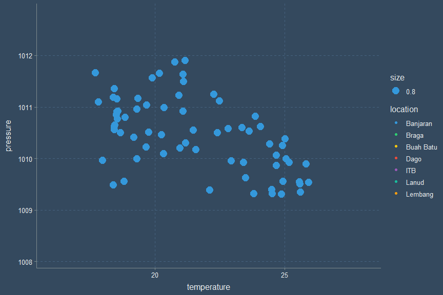

```r
animate_weather <-
  plot_weather  +
  transition_states(location) +
  ease_aes('cubic-in-out') +
  enter_grow() +
  exit_shrink()
animate_weather
```

Selamat Anda kembali berhasil membuat animasi dari grafik statis! Anda dapat menyempurnakan animasi tersebut dengan menambahkan judul grafik, sub-judul grafik, judul legenda, label sumbu x, dan label sumbu y. Isilah bagian ___ dengan judul yang menurut Anda sesuai dan jangan lupa mengisi nama Anda pada bagian `caption`!

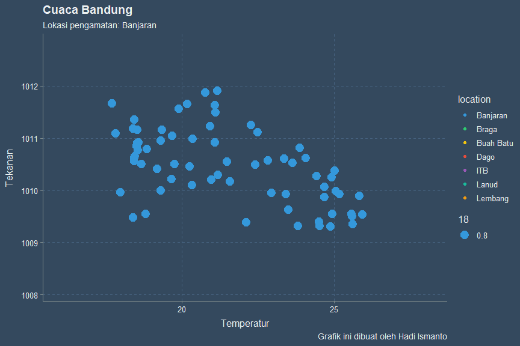

```r
animate_weather <-
  animate_weather +
  labs(
    x = "Temperatur",
    y = "Tekanan",
    title = "Cuaca Bandung",
    subtitle = "Lokasi pengamatan: {closest_state}",
    caption = "Grafik ini dibuat oleh Hadi Ismanto",
    size = "18"
  )
animate_weather
```